# TEORIA DE RESPUESTA AL ITEM

Karen López

2026-08-16 (Actualización)

EJERCICIO PRACTICO I: Importamos la librería “mirt” NOTA: Puede ser necesario instalar o actualizar otras librerías previamente.

```r
#install.packages("RcppParallel", repos = "https://cloud.r-project.org")
#install.packages("stringfish", repos = "https://cloud.r-project.org")
#install.packages("qs2", repos = "https://cloud.r-project.org")
#install.packages("SimDesign", repos = "https://cloud.r-project.org")
library(mirt)
```

Los datos que se usarán en este ejercico están incluidos en el paquete (respuestas dicotómicas) NOTA:El dataset “LSAT7” está conformado por 6 columnas, de las cuales 5 hacen referencia a los items, y una a la frecuencia de cada parton de respuesta.Conviene organizar una dataset donde cada patron de respuesta se repita, según su frecuencia

```r
data("LSAT7")
str(LSAT7)
```

```
## 'data.frame':    32 obs. of  6 variables:
##  $ Item.1: num  0 0 0 0 0 0 0 0 0 0 ...
##  $ Item.2: num  0 0 0 0 0 0 0 0 1 1 ...
##  $ Item.3: num  0 0 0 0 1 1 1 1 0 0 ...
##  $ Item.4: num  0 0 1 1 0 0 1 1 0 0 ...
##  $ Item.5: num  0 1 0 1 0 1 0 1 0 1 ...
##  $ freq  : num  12 19 1 7 3 19 3 17 10 5 ...
```

```r
head(LSAT7)
```

```
##   Item.1 Item.2 Item.3 Item.4 Item.5 freq
## 1      0      0      0      0      0   12
## 2      0      0      0      0      1   19
## 3      0      0      0      1      0    1
## 4      0      0      0      1      1    7
## 5      0      0      1      0      0    3
## 6      0      0      1      0      1   19
```

```r
datos <- LSAT7[rep(seq_len(nrow(LSAT7)), LSAT7$freq), 1:5]
head(datos)
```

```
##     Item.1 Item.2 Item.3 Item.4 Item.5
## 1        0      0      0      0      0
## 1.1      0      0      0      0      0
## 1.2      0      0      0      0      0
## 1.3      0      0      0      0      0
## 1.4      0      0      0      0      0
## 1.5      0      0      0      0      0
```

Ajustamos un modelo 2PL unidimensional teniendo en cuenta lo anterior.

```r
modelo <- mirt(datos, 1, itemtype = "2PL", freq = "freq")
```

Obtenemos los coeficientes de modleo ajustado

```r
summary(modelo)
```

```
##           F1    h2
## Item.1 0.502 0.252
## Item.2 0.536 0.287
## Item.3 0.708 0.501
## Item.4 0.410 0.168
## Item.5 0.397 0.157
##
## SS loadings:  1.366
## Proportion Var:  0.273
##
## Factor correlations:
##
##    F1
## F1  1
```

```r
coef(modelo, IRTpars = TRUE)
```

```
## $Item.1
##         a      b g u
## par 0.988 -1.879 0 1
##
## $Item.2
##         a      b g u
## par 1.081 -0.748 0 1
##
## $Item.3
##         a      b g u
## par 1.706 -1.058 0 1
##
## $Item.4
##         a      b g u
## par 0.765 -0.635 0 1
##
## $Item.5
##         a     b g u
## par 0.736 -2.52 0 1
##
## $GroupPars
##     MEAN_1 COV_11
## par      0      1
```

Si revisamos las cargas factoriales, observamos que el ítem 3 presenta la mayor carga factorial (0.708), por lo que es el ítem que tiene una relación más fuerte con la habilidad o variable latente que estamos midiendo. Por otro lado, el ítem 5 presenta la menor carga factorial (0.397), lo que indica que tiene una relación menos fuerte con dicha habilidad.

Por otra parte, si osbervamos los parametros a y b (Discriminación y Dificulatd respectivamente) tenemos que:

el item 1 tiene una baja dificultad (-1.88) y discriminación moderada (0.99), el item 2 es más dificil que el anterior (-0.75) y tiene una buena discriminación (1.1), el item 3 es el que permite mayor discrimación de los cinco evaluados (1.71), el item 4 es el más dificil de los cinco (-0.63), pero tiene baja discriminación (0.76), el item 5 es el que tiene menos dificultad (-2.52) y baja discriminación (0.74)

```r
theta <- fscores(modelo)
head(theta)
```

```
##             F1
## [1,] -1.869854
## [2,] -1.869854
## [3,] -1.869854
## [4,] -1.869854
## [5,] -1.869854
## [6,] -1.869854
```

Curva característica del ítem (ICC)

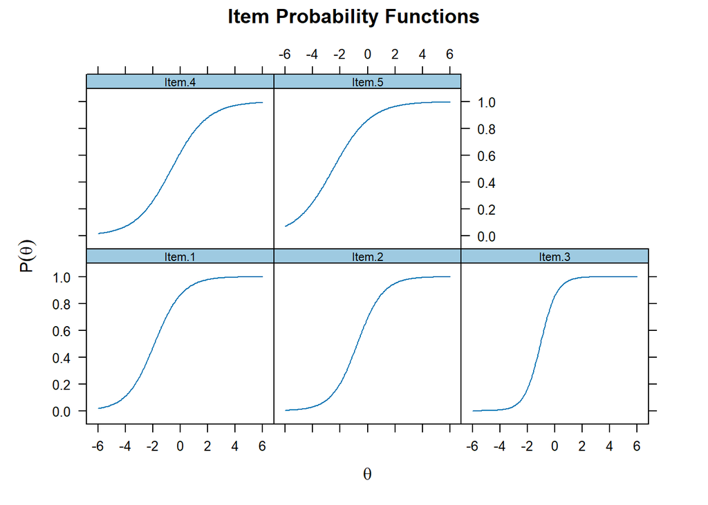

```r
plot(modelo, type = "trace")
```

[output not shown]